# PML Project

Andrea Alcala

8/14/2019

##Introduction Using devices such as Jawbone Up, Nike FuelBand, and Fitbit it is now possible to collect a large amount of data about personal activity relatively inexpensively. These type of devices are part of the quantified self movement – a group of enthusiasts who take measurements about themselves regularly to improve their health, to find patterns in their behavior, or because they are tech geeks. One thing that people regularly do is quantify how much of a particular activity they do, but they rarely quantify how well they do it. In this project, your goal will be to use data from accelerometers on the belt, forearm, arm, and dumbell of 6 participants. They were asked to perform barbell lifts correctly and incorrectly in 5 different ways.

The goal of your project is to predict the manner in which they did the exercise. This is the “classe” variable in the training set. You may use any of the other variables to predict with. You should create a report describing how you built your model, how you used cross validation, what you think the expected out of sample error is, and why you made the choices you did. You will also use your prediction model to predict 20 different test cases.

## Data loading

Load libraries and read files.

```r
library(ggplot2)
library(lubridate)
library(caret)
library(rpart)
library(randomForest)
library(dplyr)

data.train<- read.csv("pml-training.csv")
data.test<- read.csv("pml-testing.csv")
```

## Data Exploration

Check train dimensions and column names.

```r
dim(data.train)
```

```
## [1] 19622   160
```

```r
names(data.train)
```

```
##   [1] "X"                        "user_name"
##   [3] "raw_timestamp_part_1"     "raw_timestamp_part_2"
##   [5] "cvtd_timestamp"           "new_window"
##   [7] "num_window"               "roll_belt"
##   [9] "pitch_belt"               "yaw_belt"
##  [11] "total_accel_belt"         "kurtosis_roll_belt"
##  [13] "kurtosis_picth_belt"      "kurtosis_yaw_belt"
##  [15] "skewness_roll_belt"       "skewness_roll_belt.1"
##  [17] "skewness_yaw_belt"        "max_roll_belt"
##  [19] "max_picth_belt"           "max_yaw_belt"
##  [21] "min_roll_belt"            "min_pitch_belt"
##  [23] "min_yaw_belt"             "amplitude_roll_belt"
##  [25] "amplitude_pitch_belt"     "amplitude_yaw_belt"
##  [27] "var_total_accel_belt"     "avg_roll_belt"
##  [29] "stddev_roll_belt"         "var_roll_belt"
```

[output cut: 65 more lines]

Plot classe per day.

```r
data.train %>% group_by(user_name) %>% summarise(classe=length(classe))
```

```
## # A tibble: 6 x 2
##   user_name classe
##   <fct>      <int>
## 1 adelmo      3892
## 2 carlitos    3112
## 3 charles     3536
## 4 eurico      3070
## 5 jeremy      3402
## 6 pedro       2610
```

```r
data.train %>% group_by(classe) %>% summarise(count=n())
```

```
## # A tibble: 5 x 2
##   classe count
##   <fct>  <int>
## 1 A       5580
## 2 B       3797
## 3 C       3422
## 4 D       3216
## 5 E       3607
```

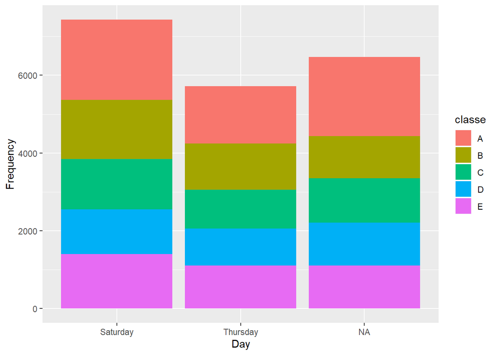

```r
data.train$cvtd_timestamp<- as.Date(data.train$cvtd_timestamp, format = "%m/%d/%Y %H:%M")
data.train$Day<-factor(weekdays(data.train$cvtd_timestamp))

qplot(x=Day, ylabel="Frequency", fill=classe, data = data.train)
```

Adelmo does most exercises. Most frequent activity is classe A.

## Data Cleaning

Remove NA columns. Remove unncessary columns (“X”, columns with “timestamp” or “window”)

```r
data.train <- data.train[, colSums(is.na(data.train)) == 0]
data.test <- data.test[, colSums(is.na(data.test)) == 0]
trainCleaned<-data.train[,-c(1:7)]
testCleaned<-data.test[,-c(1:7)]
nzv <- nearZeroVar(trainCleaned,saveMetrics=TRUE)
trainCleaned <- trainCleaned[, nzv$nzv==FALSE]
```

##Create Prediction Model (Random Forest)

```r
set.seed(1)
inTrain <- createDataPartition(trainCleaned$classe, p=0.70, list=F)
trainData <- trainCleaned[inTrain, ]
testData <- trainCleaned[-inTrain, ]
traincontrolset <- trainControl(method="cv", number=3, verboseIter=FALSE)
RFM <- train(classe ~ ., data=trainData, method="rf", trControl=traincontrolset)
RFM
```

```
## Random Forest
##
## 13737 samples
##    51 predictor
##     5 classes: 'A', 'B', 'C', 'D', 'E'
##
## No pre-processing
## Resampling: Cross-Validated (3 fold)
## Summary of sample sizes: 9159, 9157, 9158
## Resampling results across tuning parameters:
##
##   mtry  Accuracy   Kappa
##    2    0.9868238  0.9833306
##   26    0.9890077  0.9860945
##   51    0.9834752  0.9790946
##
## Accuracy was used to select the optimal model using the largest value.
## The final value used for the model was mtry = 26.
```

##Predict validation dataset. Compute for accuracy and error.

```r
predictRfmod<- predict(RFM, testData)
confusionMatrix(testData$classe, predictRfmod)
```

```
## Confusion Matrix and Statistics
##
##           Reference
## Prediction    A    B    C    D    E
##          A 1670    3    1    0    0
##          B    6 1132    0    1    0
##          C    0   10 1010    6    0
##          D    0    0   13  950    1
##          E    0    0    0    4 1078
##
## Overall Statistics
##
##                Accuracy : 0.9924
##                  95% CI : (0.9898, 0.9944)
##     No Information Rate : 0.2848
##     P-Value [Acc > NIR] : < 2.2e-16
##
##                   Kappa : 0.9903
##
##  Mcnemar's Test P-Value : NA
##
## Statistics by Class:
##
##                      Class: A Class: B Class: C Class: D Class: E
## Sensitivity            0.9964   0.9886   0.9863   0.9886   0.9991
## Specificity            0.9990   0.9985   0.9967   0.9972   0.9992
## Pos Pred Value         0.9976   0.9939   0.9844   0.9855   0.9963
## Neg Pred Value         0.9986   0.9973   0.9971   0.9978   0.9998
## Prevalence             0.2848   0.1946   0.1740   0.1633   0.1833
## Detection Rate         0.2838   0.1924   0.1716   0.1614   0.1832
## Detection Prevalence   0.2845   0.1935   0.1743   0.1638   0.1839
## Balanced Accuracy      0.9977   0.9936   0.9915   0.9929   0.9991
```

```r
postResample(predictRfmod, testData$classe)
```

```
##  Accuracy     Kappa
## 0.9923534 0.9903274
```

```r
1 - as.numeric(confusionMatrix(testData$classe, predictRfmod)$overall[1])
```

```
## [1] 0.007646559
```

##Predict test dataset

```r
result <- predict(RFM, testCleaned)
result
```

```
##  [1] B A A A A E D B A A B C B A E E A B B B
## Levels: A B C D E
```